# COVID-19 South Korea

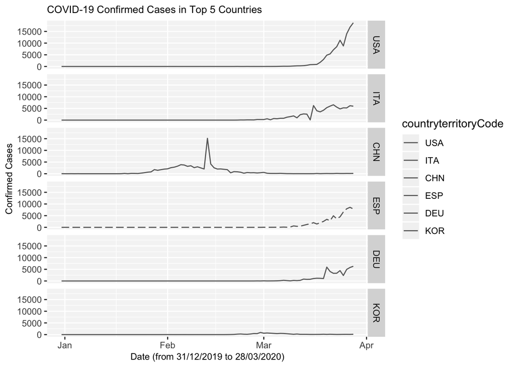

```r
covid1.korea <- covid1 %>%
  filter(countryterritoryCode =="KOR")


ggplot(covid1, aes(x = dateRep, y = cases, color = countryterritoryCode)) +
  geom_line(linetype = ifelse(covid1$countryterritoryCode == "KOR", "longdash", "solid")) +
  scale_color_manual(values = c("dimgrey", "dimgrey", "dimgrey", "dimgrey", "dimgrey", "dimgrey")) +
  facet_grid(countryterritoryCode ~ .) +
  labs(title = "COVID-19 Confirmed Cases in Top 5 Countries", x = "Date (from 31/12/2019 to 28/03/2020)", y = "Confirmed Cases") +
  theme(panel.background = element_rect(fill = "grey96"), plot.title = element_text(size=10), axis.title.x = element_text(size = 9), axis.title.y = element_text(size = 9))
```

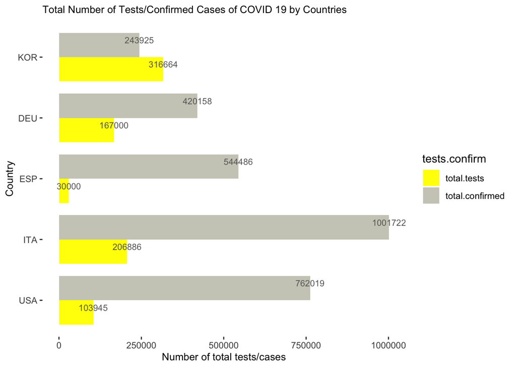

```r
# total tests vs total confirmed cases
#
test1 <- test %>%
  filter(Code == "ITA"| Code == "ESP"| Code == "DEU"|Code == "KOR" |Code == "USA")

test1 <- test1 %>%
  group_by(Code) %>%
  summarize(total.tests = sum(Total.COVID.19.tests), total.confirmed = sum(Total.confirmed.cases.of.COVID.19..cases.)) %>%
  gather(key = "tests.confirm", value = count, total.tests, total.confirmed)
test1$Code <- factor(test1$Code, levels = c("USA", "ITA", "ESP","DEU", "KOR"))
test1$tests.confirm <- factor(test1$tests.confirm, levels = c("total.tests", "total.confirmed"))

#
bar.total1 <- ggplot(test1, aes(x = Code, y = count, fill = tests.confirm)) +
  geom_bar(stat = "identity", position = "dodge", width = 0.8) +
  labs(title = "Total Number of Tests/Confirmed Cases of COVID 19 by Countries", x = "Country", y = "Number of total tests/cases") +
  scale_fill_manual(values = c("yellow","ivory3")) +
  scale_color_manual(values = c("yellow", "ivory3")) +
  theme(panel.background = element_rect(fill = "white"), plot.title = element_text(size=10), axis.title.x = element_text(size = 10), axis.title.y = element_text(size = 10)) +
  geom_text(
    aes(label = count, group = tests.confirm),
    position = position_dodge(0.8),
    vjust = -0.3, size = 3.0, color = "grey41"
  ) +
  coord_flip()
bar.total1
```

The first confirmed case of the pandemic of COVID-19 in South Korea was announced on 20 January 2020. On 19 February, the number of confirmed cases increased by 20 and on 20 February by 58 or 70, giving a total of 346 confirmed cases on 21 February 2020 according to the Centers for Disease Control and Prevention Korea (KCDC), with the sudden jump mostly attributed to “Patient 31” who participated in a gathering at a Shincheonji Church in Daegu

### Flatten the Curve

```r
covid1.korea$dateRep <- as.Date(covid1.korea$dateRep)

covid1.korea <- arrange(covid1.korea, dateRep)

covid1.korea1 <- covid1.korea[-c(1:20),]

# days.1to15
days.1to36 <- 1:36
cases.1to36 <-covid1.korea1[c(1:36),5]


# days.16to30
days.37to69 <- 37:69
days.drivethru1 <- 0:32
cases.37to69 <- round(130*(1.17^days.drivethru1), digits=0)


# days.1to30
days.1to69 <- c(days.1to36, days.37to69)
cases.1to69 <- c(cases.1to36, cases.37to69)


# social distancing
days.drivethru <- 37:69
cases.drivethru <- covid1.korea1[c(37:69),5]


#
```

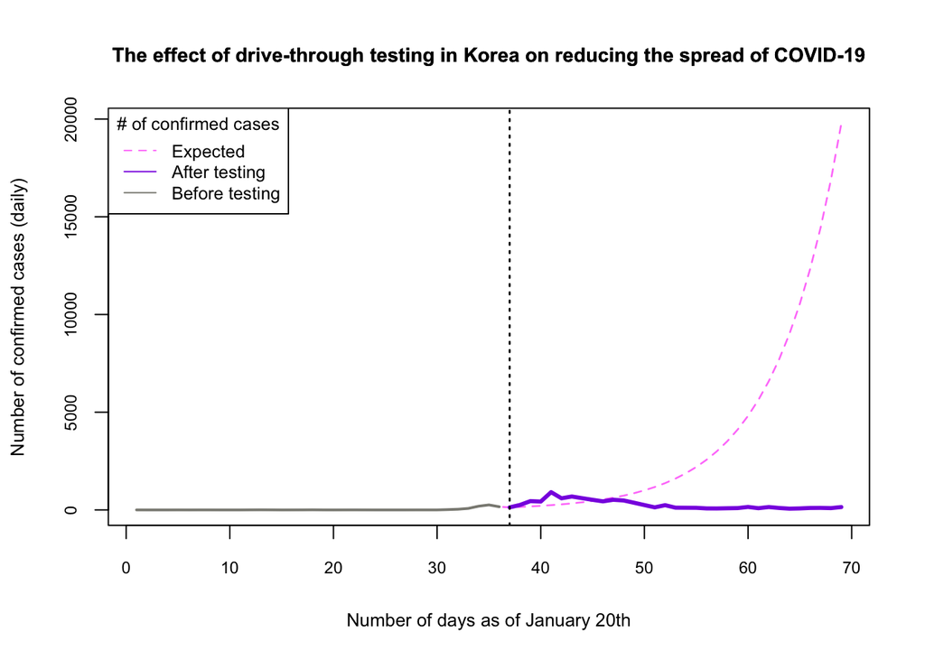

```r
plot(days.1to69, cases.1to69, type = "l", frame = TRUE, lty = 2, lwd = 0.6, col = "orchid1", xlab = "Number of days as of January 20th", ylab = "Number of confirmed cases (daily)", cex.lab = 0.83, cex.axis = 0.75)
lines(days.1to69, cases.1to69, type = "l", lty = 2, lwd = 1.3, col = "orchid1", xlab = "Days", ylab = "Confirmed Cases")
lines(x=days.1to36, y=cases.1to36, col = "ivory4", type = "l", lwd = 2, lty=1)
lines(x=days.drivethru, y=cases.drivethru, col = "blueviolet", lwd = 3)
legend("topleft", legend = c("Expected", "After testing", "Before testing"), col = c("orchid1", "blueviolet", "ivory4"), lty = c(2,1,1), cex=0.8, title = "# of confirmed cases")
title("The effect of drive-through testing in Korea on reducing the spread of COVID-19", font.main = 2, cex.main = 0.9)
title("The effect of drive-through testing in Korea on reducing the spread of COVID-19", font.main = 2, cex.main = 0.9)
abline(v = 37, col = "black", lwd = 1.5, lty = 3)
```

```r
# create epidemic curve to observe the timeline of COVID 19
# change the level of dateRep to date
#covid1$dateRep <- as.Date(covid1$dateRep)


# convert covid1 dataframe to longer dataframe for analysis
#covid1.combined <- covid1 %>%
  #gather(key = "case.or.death", value = count, cases, deaths)

# filter cases
#covid1.deaths <- covid1.combined %>%
  #filter(covid1.combined$case.or.death == "deaths") %>%
  #group_by(dateRep) %>%
  #summarize(death.total = sum(count))

#covid1.cases <- covid1.combined %>%
  #filter(covid1.combined$case.or.death == "cases") %>%
  #group_by(dateRep) %>%
  #summarize(case.total = sum(count))

# prepare dataframe to make epicurve
#epicurve.data <- cbind(covid1.cases, covid1.deaths[,2])
#epicurve.data <- epicurve.data %>%
  #gather(key = "cases.deaths", value = count, case.total, death.total)
#epicurve.data$cases.deaths <- as.factor(epicurve.data$cases.deaths)
#str(epicurve.data)

# epicurve
#library(EpiCurve)
#EpiCurve(covid1,
      #   date = "dateRep",
       #  freq = "cases",
        # period = "day",
         #ylabel = "Number of cases",
         #xlabel = sprintf("From %s to %s", min(epicurve.data$dateRep), max(epicurve.data$dateRep)))

#incidence.fit <- incidence::fit(epicurve.data, split = NULL)
#plot(epicurve.data) %>% add_incidence_fit(incidence.fit)
```